# Part 2 Decision Tree

Harrison Cradduck, Nick Berry

2025-11-05

# 1 Introduction

**Using the pruning method we discussed in class, develop the best single decision tree model that you can. You may experiment with different trees until you find the one that is the best in terms of prediction.**

# 2 Data Loading

Load in the training and holdout data sets tailored for Part 2 (tree-based models).

```r
# read in .csv training data file
data_train <- readRDS("../data/final_cleaned_train_part2.rds")
```

```r
# read in .csv holdout data file
data_holdout <- readRDS("../data/final_cleaned_holdout_part2.rds")
```

## 2.1 Dummy-coding

Create training and holdout data sets with dummy-coded factor variables.

```r
# set response variable
response <- "loan_default"

# set predictor variables
predictor_cols <- setdiff(names(data_train), response)

# create dummy variables for all factor columns in data_train
data_train_dummy <- fastDummies::dummy_cols(
  data_train[, predictor_cols],
  remove_first_dummy = FALSE,
  remove_selected_columns = TRUE
)
data_train_dummy[[response]] <- data_train[[response]]

colnames(data_train_dummy) <- make.names(colnames(data_train_dummy))

# create dummy variables for all factor columns in data_holdout
data_holdout_dummy <- fastDummies::dummy_cols(
  data_holdout[, predictor_cols],
  remove_first_dummy = FALSE,
  remove_selected_columns = TRUE
)
data_holdout_dummy[[response]] <- data_holdout[[response]]

colnames(data_holdout_dummy) <- make.names(colnames(data_train_dummy))
```

## 2.2 Downsampling

Create a downsampled training data set and a downsampled dummy-coded training data set by undersampling the majority class of `loan_default`.

```r
# down-sample the training data
data_train_ds <- ovun.sample(loan_default ~ ., data = data_train, method = "under")$data
```

```r
# down-sample the dummy training data
data_train_dummy_ds <- ovun.sample(loan_default ~ ., data = data_train_dummy, method = "under")$data
```

# 3 Modeling

```r
# set seed for reproducibility
set.seed(123)
```

## 3.1 Initial Decision Tree

```r
# fit a single decision tree
d_tree1 <- rpart::rpart(
  loan_default ~ .,
  data = data_train,
  method = "class",
  control = rpart::rpart.control(xval = 10))

# select the best pruned tree
d_tree1_opt_cp <- d_tree1$cptable[which.min(d_tree1$cptable[,"xerror"]), "CP"]
d_tree1_pruned <- rpart::prune(d_tree1, cp = d_tree1_opt_cp)

# predict on holdout data
d_tree1_pred_prob <- predict(d_tree1_pruned, data_holdout, type = "prob")[, "Yes"]
d_tree1_pred_class <- predict(d_tree1_pruned, data_holdout, type = "class")

# produce a confusion matrix
confusionMatrix(d_tree1_pred_class, data_holdout$loan_default, positive = "Yes")
```

```
## Confusion Matrix and Statistics
##
##           Reference
## Prediction    No   Yes
##        No  61158 10933
##        Yes  2505  4603
##
##                Accuracy : 0.8303
##                  95% CI : (0.8277, 0.8329)
##     No Information Rate : 0.8038
##     P-Value [Acc > NIR] : < 2.2e-16
##
##                   Kappa : 0.3232
##
##  Mcnemar's Test P-Value : < 2.2e-16
##
##             Sensitivity : 0.29628
##             Specificity : 0.96065
##          Pos Pred Value : 0.64758
##          Neg Pred Value : 0.84834
##              Prevalence : 0.19616
##          Detection Rate : 0.05812
##    Detection Prevalence : 0.08975
##       Balanced Accuracy : 0.62847
##
##        'Positive' Class : Yes
##
```

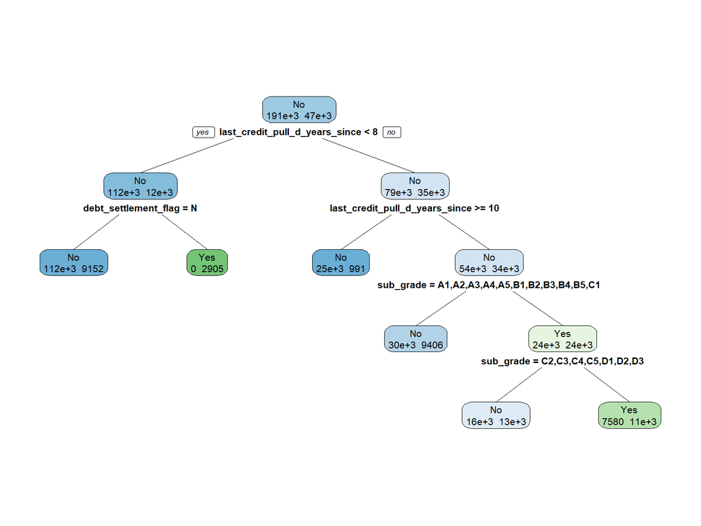

```r
# plot decision tree
rpart.plot::rpart.plot(d_tree1_pruned, type = 2, extra = 1, fallen.leaves = FALSE)
```

**We fit a single, cross-validated decision tree using the original training data set, then pruned it, made predictions on it using the holdout data set, and outputted the confusion matrix and the decision tree plot for the pruned tree. The depth of the tree is 4 (4 splits). The metrics are as follows: accuracy = 0.83, sensitivity = 0.296, and specificity = 0.961.**

## 3.2 Down-sampled Decision Tree

```r
# fit a single decision tree
d_tree2 <- rpart::rpart(
  loan_default ~ .,
  data = data_train_ds,
  method = "class",
  control = rpart::rpart.control(xval = 10))

# select the best pruned tree
d_tree2_opt_cp <- d_tree2$cptable[which.min(d_tree2$cptable[,"xerror"]), "CP"]
d_tree2_pruned <- rpart::prune(d_tree2, cp = d_tree2_opt_cp)

# predict on holdout data
d_tree2_pred_prob <- predict(d_tree2_pruned, data_holdout, type = "prob")[, "Yes"]
d_tree2_pred_class <- predict(d_tree2_pruned, data_holdout, type = "class")

# produce a confusion matrix
confusionMatrix(d_tree2_pred_class, data_holdout$loan_default, positive = "Yes")
```

```
## Confusion Matrix and Statistics
##
##           Reference
## Prediction    No   Yes
##        No  45788  3422
##        Yes 17875 12114
##
##                Accuracy : 0.7311
##                  95% CI : (0.728, 0.7342)
##     No Information Rate : 0.8038
##     P-Value [Acc > NIR] : 1
##
##                   Kappa : 0.3692
##
##  Mcnemar's Test P-Value : <2e-16
##
##             Sensitivity : 0.7797
##             Specificity : 0.7192
##          Pos Pred Value : 0.4039
##          Neg Pred Value : 0.9305
##              Prevalence : 0.1962
##          Detection Rate : 0.1530
##    Detection Prevalence : 0.3787
##       Balanced Accuracy : 0.7495
##
##        'Positive' Class : Yes
##
```

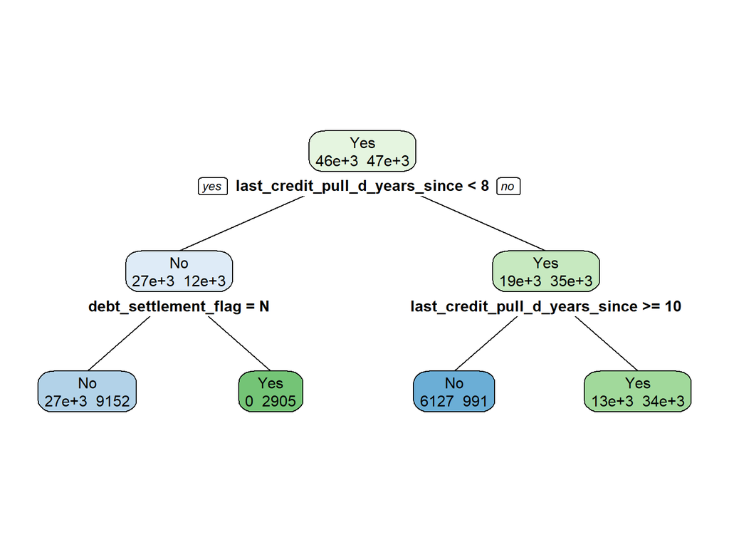

```r
# plot decision tree
rpart.plot::rpart.plot(d_tree2_pruned, type = 2, extra = 1, fallen.leaves = FALSE)
```

**We fit a single, cross-validated decision tree using the downsampled training data set, then pruned it, made predictions on it using the holdout data set, and outputted the confusion matrix and the decision tree plot for the pruned tree. The depth of the tree is 2 (2 splits). The metrics are as follows: accuracy = 0.73, sensitivity = 0.78, and specificity = 0.72.**

## 3.3 Dummy-coded Decision Tree

```r
# fit a single decision tree
d_tree3 <- rpart::rpart(
  loan_default ~ .,
  data = data_train_dummy,
  method = "class",
  control = rpart::rpart.control(xval = 10))

# select the best pruned tree
d_tree3_opt_cp <- d_tree3$cptable[which.min(d_tree3$cptable[,"xerror"]), "CP"]
d_tree3_pruned <- rpart::prune(d_tree3, cp = d_tree3_opt_cp)

# predict on holdout data
d_tree3_pred_prob <- predict(d_tree3_pruned, data_holdout_dummy, type = "prob")[, "Yes"]
d_tree3_pred_class <- predict(d_tree3_pruned, data_holdout_dummy, type = "class")

# produce a confusion matrix
confusionMatrix(d_tree3_pred_class, data_holdout_dummy$loan_default, positive = "Yes")
```

```
## Confusion Matrix and Statistics
##
##           Reference
## Prediction    No   Yes
##        No  59805  9246
##        Yes  3858  6290
##
##                Accuracy : 0.8345
##                  95% CI : (0.8319, 0.8371)
##     No Information Rate : 0.8038
##     P-Value [Acc > NIR] : < 2.2e-16
##
##                   Kappa : 0.3962
##
##  Mcnemar's Test P-Value : < 2.2e-16
##
##             Sensitivity : 0.40487
##             Specificity : 0.93940
##          Pos Pred Value : 0.61983
##          Neg Pred Value : 0.86610
##              Prevalence : 0.19616
##          Detection Rate : 0.07942
##    Detection Prevalence : 0.12813
##       Balanced Accuracy : 0.67213
##
##        'Positive' Class : Yes
##
```

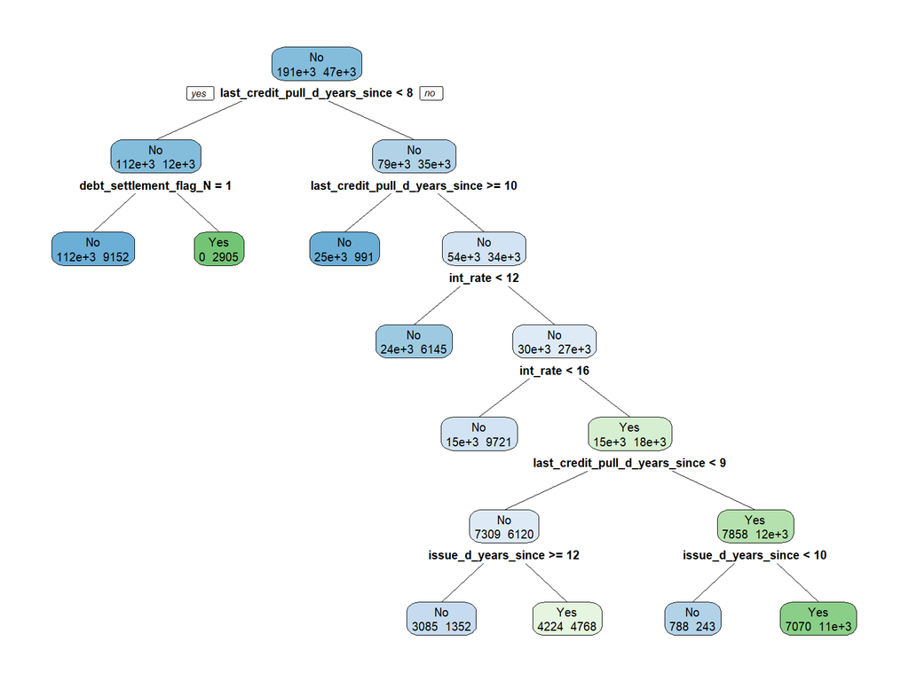

```r
# plot decision tree
rpart.plot::rpart.plot(d_tree3_pruned, type = 2, extra = 1, fallen.leaves = FALSE)
```

**We fit a single, cross-validated decision tree using the dummy-coded training data set, then pruned it, made predictions on it using the holdout data set, and outputted the confusion matrix and the decision tree plot for the pruned tree. The depth of the tree is 6 (6 splits). The metrics are as follows: accuracy = 0.835, sensitivity = 0.405, and specificity = 0.939.**

## 3.4 Dummy-coded + Downsampled Decision Tree

```r
# fit a single decision tree
d_tree4 <- rpart::rpart(
  loan_default ~ .,
  data = data_train_dummy_ds,
  method = "class",
  control = rpart::rpart.control(xval = 10))

# select the best pruned tree
d_tree4_opt_cp <- d_tree4$cptable[which.min(d_tree4$cptable[,"xerror"]), "CP"]
d_tree4_pruned <- rpart::prune(d_tree4, cp = d_tree4_opt_cp)

# predict on holdout data
d_tree4_pred_prob <- predict(d_tree4_pruned, data_holdout_dummy, type = "prob")[, "Yes"]
d_tree4_pred_class <- predict(d_tree4_pruned, data_holdout_dummy, type = "class")

# produce a confusion matrix
confusionMatrix(d_tree4_pred_class, data_holdout_dummy$loan_default, positive = "Yes")
```

```
## Confusion Matrix and Statistics
##
##           Reference
## Prediction    No   Yes
##        No  45788  3422
##        Yes 17875 12114
##
##                Accuracy : 0.7311
##                  95% CI : (0.728, 0.7342)
##     No Information Rate : 0.8038
##     P-Value [Acc > NIR] : 1
##
##                   Kappa : 0.3692
##
##  Mcnemar's Test P-Value : <2e-16
##
##             Sensitivity : 0.7797
##             Specificity : 0.7192
##          Pos Pred Value : 0.4039
##          Neg Pred Value : 0.9305
##              Prevalence : 0.1962
##          Detection Rate : 0.1530
##    Detection Prevalence : 0.3787
##       Balanced Accuracy : 0.7495
##
##        'Positive' Class : Yes
##
```

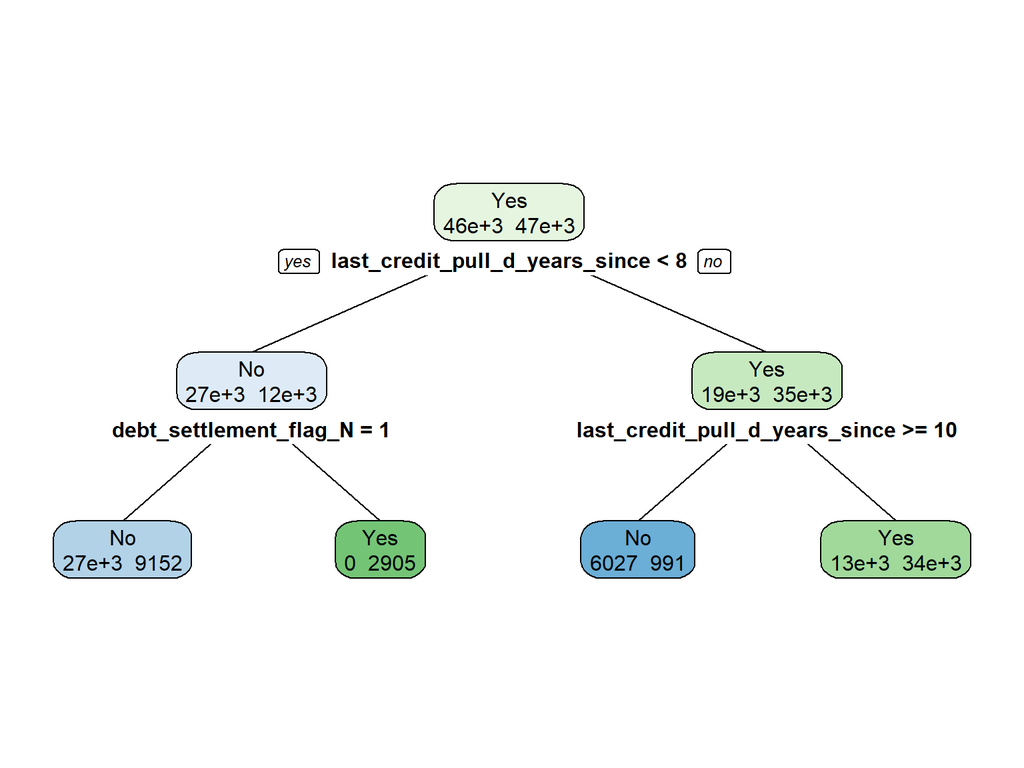

```r
# plot decision tree
rpart.plot::rpart.plot(d_tree4_pruned, type = 2, extra = 1, fallen.leaves = FALSE)
```

**We fit a single, cross-validated decision tree using the downsampled, dummy-coded training data set, then pruned it, made predictions on it using the holdout data set, and outputted the confusion matrix and the decision tree plot for the pruned tree. The depth of the tree is 2 (2 splits). The metrics are as follows: accuracy = 0.731, sensitivity = 0.78, and specificity = 0.719.**

## 3.5 Decision Tree Hyperparameter Tuning

Develop a function to perform hyperparameter tuning (using cp, minsplit, maxdepth, and split parameters) on the decision trees.

```r
# create a function to perform hyperparameter tuning on a given training data set
run_grid_search <- function(data_train,
                            data_holdout,
                            cps = c(0.001, 0.01, 0.05, 0.1),
                            minsplits = c(10, 20, 30),
                            maxdepths = c(3, 5, 7, 10),
                            splits = c("gini", "information")) {

  results_list <- list()
  i <- 1

  for (split in splits) {
    for (cp in cps) {
      for (minsplit in minsplits) {
        for (maxdepth in maxdepths) {

          # fit a tree
          tree <- rpart::rpart(
            loan_default ~ .,
            data = data_train,
            method = "class",
            parms = list(split = split),
            control = rpart::rpart.control(
              cp = cp,
              minsplit = minsplit,
              maxdepth = maxdepth,
              xval = 10
            )
          )

          # prune using optimal cp from cross-validation
          opt_cp <- tree$cptable[which.min(tree$cptable[,"xerror"]), "CP"]
          pruned_tree <- rpart::prune(tree, cp = opt_cp)

          # predict probabilities on holdout
          pred_prob <- predict(pruned_tree, data_holdout, type = "prob")[, "Yes"]

          # calculate AUC
          roc_obj <- pROC::roc(data_holdout$loan_default, pred_prob, quiet = TRUE)
          auc <- as.numeric(pROC::auc(roc_obj))

          pred_class <- factor(ifelse(pred_prob > 0.5, "Yes", "No"), levels = c("No", "Yes"))

          cm <- confusionMatrix(pred_class, data_holdout$loan_default, positive = "Yes")

          # extract metrics
          precision <- as.numeric(cm$byClass["Precision"])
          recall <- as.numeric(cm$byClass["Sensitivity"])
          accuracy <- as.numeric(cm$overall["Accuracy"])
          f1 <- ifelse((precision + recall) == 0, 0, 2 * (precision * recall) / (precision + recall))

          # place metrics in results data frame for comparison
          results_list[[i]] <- data.frame(
            split = split,
            cp = cp,
            minsplit = minsplit,
            maxdepth = maxdepth,
            precision = precision,
            recall = recall,
            accuracy = accuracy,
            AUC = auc,
            F1 = f1
          )
          i <- i + 1
        }
      }
    }
  }

  # combine all results and add row names
  results <- do.call(rbind, results_list)
  rownames(results) <- paste0("tree", seq_len(nrow(results)))

  # sort by F1 descending
  results <- results[order(-results$F1), ]

  return(results)
}
```

### 3.5.1 Pruned Decision Tree on Original Data

```r
# # original train data
# results_og <- run_grid_search(data_train = data_train, data_holdout = data_holdout)
#
# head(results_og)
```

**The best single, cross-validated decision tree selected by hyperparameter tuning on the original training set is fit with the following hyperparameters: split = “gini”, cp = 0.001, minsplit = 10, and maxdepth = 3. The metrics are as follows: precision = 0.53, recall = 0.577, accuracy = 0.817, AUC = 0.793, and F1 = 0.553.**

```r
# # refit best model on original training data for plotting and saving
# best_row <- results_og[1, ]
# best_tree_og <- rpart::rpart(
#   loan_default ~ .,
#   data = data_train,
#   method = "class",
#   control = rpart::rpart.control(cp = best_row$cp,
#                                  minsplit = best_row$minsplit,
#                                  maxdepth = best_row$maxdepth,
#                                  xval = 10)
# )
#
# rpart.plot::rpart.plot(best_tree_og, type = 2, extra = 1, fallen.leaves = TRUE, digits = 3)
#
# # save best model so we don't need to refit it and can compare against others
# saveRDS(best_tree_og, "original_best_tree.rds")
```

**The best single, cross-validated decision tree selected by hyperparameter tuning on the original training set has a depth of 3 (3 splits).**

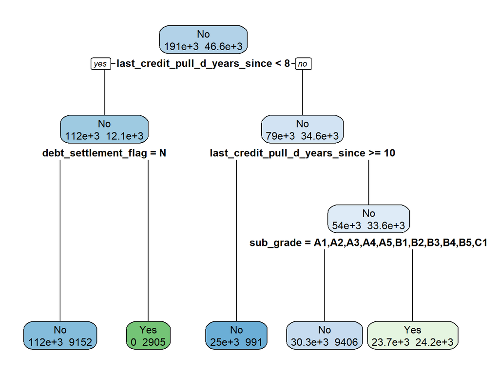

```r
# read in .rds file to avoid refitting
best_tree_og <- read_rds("../part2_files/original_best_tree.rds")
rpart.plot::rpart.plot(best_tree_og, type = 2, extra = 1, fallen.leaves = TRUE, digits = 3)
```

```r
# get actual classes and predicted probabilities on holdout
pred_probs <- predict(best_tree_og, data_holdout, type = "prob")[, "Yes"]
true_labels <- ifelse(data_holdout$loan_default == "Yes", 1, 0)

# get prediction
pred <- ROCR::prediction(pred_probs, true_labels)

# compute metrics on thresholds
perf <- ROCR::performance(pred, measure = "prec", x.measure = "rec")
precision <- perf@y.values[[1]]
recall <- perf@x.values[[1]]
thresholds <- perf@alpha.values[[1]]

# calculate f1
f1 <- 2 * (precision * recall) / (precision + recall)
f1[is.nan(f1)] <- 0

# find best threshold and f1
best_index_og <- which.max(f1)
best_thresh_og <- thresholds[best_index_og]
best_f1_og <- f1[best_index_og]

# print best threshold and f1
cat("Best threshold:", best_thresh_og, "\n")
```

```
## Best threshold: 0.5049838
```

```r
cat("Best F1 score:", best_f1_og, "\n")
```

```
## Best F1 score: 0.5528781
```

```r
final_pred <- ifelse(pred_probs >= best_thresh_og, "Yes", "No")
confusionMatrix(factor(final_pred, levels = c("No", "Yes")),
                       data_holdout$loan_default,
                       positive = "Yes")
```

```
## Confusion Matrix and Statistics
##
##           Reference
## Prediction    No   Yes
##        No  55718  6565
##        Yes  7945  8971
##
##                Accuracy : 0.8168
##                  95% CI : (0.8141, 0.8195)
##     No Information Rate : 0.8038
##     P-Value [Acc > NIR] : < 2.2e-16
##
##                   Kappa : 0.4379
##
##  Mcnemar's Test P-Value : < 2.2e-16
##
##             Sensitivity : 0.5774
##             Specificity : 0.8752
##          Pos Pred Value : 0.5303
##          Neg Pred Value : 0.8946
##              Prevalence : 0.1962
##          Detection Rate : 0.1133
##    Detection Prevalence : 0.2136
##       Balanced Accuracy : 0.7263
##
##        'Positive' Class : Yes
##
```

**Finding the optimal threshold by F1 score for the best single, cross-validated decision tree selected by hyperparameter tuning on the original training set results in an optimal threshold of 0.505 and an F1 score of 0.553. The metrics are as follows: accuracy = 0.817, sensitivity = 0.577, and specificity = 0.875.**

### 3.5.2 Pruned Decision Tree on Downsampled Data

```r
# # downsampled train data
# results_ds <- run_grid_search(data_train = data_train_ds, data_holdout = data_holdout)
#
# head(results_ds)
```

```r
# # refit best model on downsampled training data for plotting and saving
# best_row <- results_ds[1, ]
# best_tree_ds <- rpart::rpart(
#   loan_default ~ .,
#   data = data_train_ds,
#   method = "class",
#   control = rpart::rpart.control(cp = best_row$cp,
#                                  minsplit = best_row$minsplit,
#                                  maxdepth = best_row$maxdepth,
#                                  xval = 10)
# )
#
# rpart.plot::rpart.plot(best_tree_ds, type = 2, extra = 1, fallen.leaves = TRUE, digits = 3)
#
# # save best model so we don't need to refit it and can compare against others
# saveRDS(best_tree_ds, "downsampled_best_tree.rds")
```

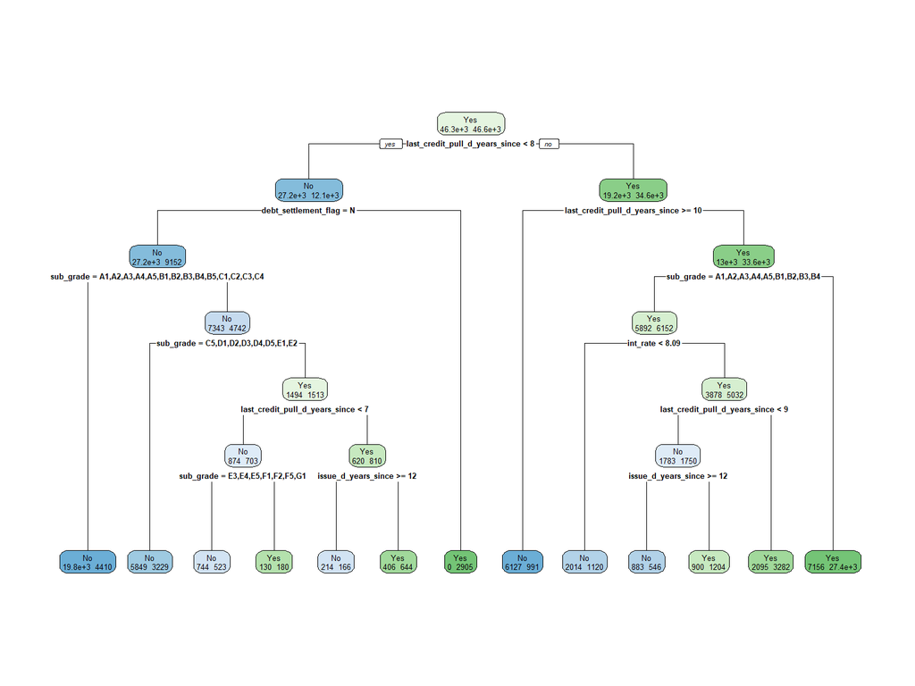

```r
# read in .rds file to avoid refitting
best_tree_ds <- read_rds("../part2_files/downsampled_best_tree.rds")
rpart.plot::rpart.plot(best_tree_ds, type = 2, extra = 1, fallen.leaves = TRUE, digits = 3)
```

```r
# get actual classes and predicted probabilities on holdout
pred_probs <- predict(best_tree_ds, data_holdout, type = "prob")[, "Yes"]
true_labels <- ifelse(data_holdout$loan_default == "Yes", 1, 0)

# get prediction
pred <- ROCR::prediction(pred_probs, true_labels)

# compute metrics on thresholds
perf <- ROCR::performance(pred, measure = "prec", x.measure = "rec")
precision <- perf@y.values[[1]]
recall <- perf@x.values[[1]]
thresholds <- perf@alpha.values[[1]]

# calculate f1
f1 <- 2 * (precision * recall) / (precision + recall)
f1[is.nan(f1)] <- 0

# find best threshold and f1
best_index_ds <- which.max(f1)
best_thresh_ds <- thresholds[best_index_ds]
best_f1_ds <- f1[best_index_ds]

# print best threshold and f1
cat("Best threshold:", best_thresh_ds, "\n")
```

```
## Best threshold: 0.6103775
```

```r
cat("Best F1 score:", best_f1_ds, "\n")
```

```
## Best F1 score: 0.5651818
```

```r
final_pred <- ifelse(pred_probs >= best_thresh_ds, "Yes", "No")
confusionMatrix(factor(final_pred, levels = c("No", "Yes")),
                       data_holdout$loan_default,
                       positive = "Yes")
```

```
## Confusion Matrix and Statistics
##
##           Reference
## Prediction    No   Yes
##        No  50258  4136
##        Yes 13405 11400
##
##                Accuracy : 0.7785
##                  95% CI : (0.7756, 0.7814)
##     No Information Rate : 0.8038
##     P-Value [Acc > NIR] : 1
##
##                   Kappa : 0.4269
##
##  Mcnemar's Test P-Value : <2e-16
##
##             Sensitivity : 0.7338
##             Specificity : 0.7894
##          Pos Pred Value : 0.4596
##          Neg Pred Value : 0.9240
##              Prevalence : 0.1962
##          Detection Rate : 0.1439
##    Detection Prevalence : 0.3132
##       Balanced Accuracy : 0.7616
##
##        'Positive' Class : Yes
##
```

**Finding the optimal threshold by F1 score for the best single, cross-validated decision tree selected by hyperparameter tuning on the downsampled training set results in an optimal threshold of 0.61 and an F1 score of 0.565. The metrics are as follows: accuracy = 0.779, sensitivity = 0.734, and specificity = 0.789.**

### 3.5.3 Pruned Decision Tree on Dummy-coded Data

```r
# dummy-coded train data
# results_dummy <- run_grid_search(data_train = data_train_dummy, data_holdout = data_holdout_dummy, cps = c(0.001)) # limit cps to best performing cp in models above for sake of time
#
# head(results_dummy)
```

**The best single, cross-validated decision tree selected by hyperparameter tuning on the dummy-coded training set is fit with the following hyperparameters: split = “gini”, cp = 0.001, minsplit = 10, and maxdepth = 10. The metrics are as follows: precision = 0.626, recall = 0.439, accuracy = 0.838, AUC = 0.804, and F1 = 0.526.**

```r
# # refit best model on dummy-coded training data for plotting and saving
# best_row <- results_dummy[1, ]
# best_tree_dummy <- rpart::rpart(
#   loan_default ~ .,
#   data = data_train_dummy,
#   method = "class",
#   control = rpart::rpart.control(cp = best_row$cp,
#                                  minsplit = best_row$minsplit,
#                                  maxdepth = best_row$maxdepth,
#                                  xval = 10)
# )
#
# rpart.plot::rpart.plot(best_tree_dummy, type = 2, extra = 1, fallen.leaves = TRUE, digits = 3)
#
# # save best model so we don't need to refit it and can compare against others
# saveRDS(best_tree_dummy, "dummy_best_tree.rds")
```

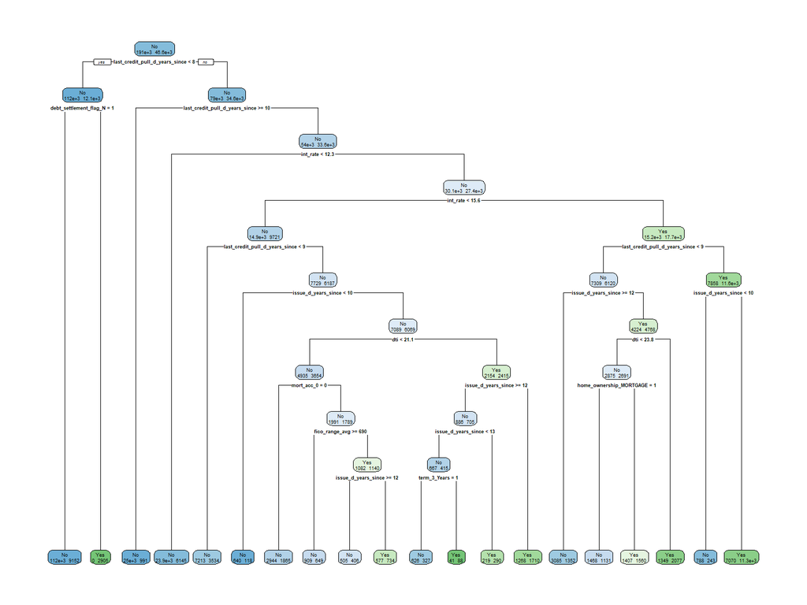

```r
# read in .rds file to avoid refitting
best_tree_dummy <- read_rds("../part2_files/dummy_best_tree.rds")
rpart.plot::rpart.plot(best_tree_dummy, type = 2, extra = 1, fallen.leaves = TRUE, digits = 3)
```

```r
# get actual classes and predicted probabilities on holdout
pred_probs <- predict(best_tree_dummy, data_holdout_dummy, type = "prob")[, "Yes"]
true_labels <- ifelse(data_holdout_dummy$loan_default == "Yes", 1, 0)

# get prediction
pred <- ROCR::prediction(pred_probs, true_labels)

# compute metrics on thresholds
perf <- ROCR::performance(pred, measure = "prec", x.measure = "rec")
precision <- perf@y.values[[1]]
recall <- perf@x.values[[1]]
thresholds <- perf@alpha.values[[1]]

# calculate f1
f1 <- 2 * (precision * recall) / (precision + recall)
f1[is.nan(f1)] <- 0

# find best threshold and f1
best_index_dummy <- which.max(f1)
best_thresh_dummy <- thresholds[best_index_dummy]
best_f1_dummy <- f1[best_index_dummy]

# print best threshold and f1
cat("Best threshold:", best_thresh_dummy, "\n")
```

```
## Best threshold: 0.3047104
```

```r
cat("Best F1 score:", best_f1_dummy, "\n")
```

```
## Best F1 score: 0.5666049
```

```r
final_pred <- ifelse(pred_probs >= best_thresh_dummy, "Yes", "No")
confusionMatrix(factor(final_pred, levels = c("No", "Yes")),
                       data_holdout_dummy$loan_default,
                       positive = "Yes")
```

```
## Confusion Matrix and Statistics
##
##           Reference
## Prediction    No   Yes
##        No  54068  5602
##        Yes  9595  9934
##
##                Accuracy : 0.8081
##                  95% CI : (0.8054, 0.8109)
##     No Information Rate : 0.8038
##     P-Value [Acc > NIR] : 0.001197
##
##                   Kappa : 0.4454
##
##  Mcnemar's Test P-Value : < 2.2e-16
##
##             Sensitivity : 0.6394
##             Specificity : 0.8493
##          Pos Pred Value : 0.5087
##          Neg Pred Value : 0.9061
##              Prevalence : 0.1962
##          Detection Rate : 0.1254
##    Detection Prevalence : 0.2466
##       Balanced Accuracy : 0.7444
##
##        'Positive' Class : Yes
##
```

**Finding the optimal threshold by F1 score for the best single, cross-validated decision tree selected by hyperparameter tuning on the dummy-coded training set results in an optimal threshold of 0.305 and an F1 score of 0.567. The metrics are as follows: accuracy = 0.808, sensitivity = 0.639, and specificity = 0.849.**

### 3.5.4 Pruned Decision Tree on Dummy-coded Downsampled Data

```r
# # down-sampled dummy-coded train data
# results_ds_dummy <- run_grid_search(data_train = data_train_dummy_ds, data_holdout = data_holdout_dummy, cps = c(0.001)) # limit cps to best performing cp in models above for sake of time
#
# head(results_ds_dummy)
```

**The best single, cross-validated decision tree selected by hyperparameter tuning on the downsampled dummy-coded training set is fit with the following hyperparameters: split = “gini”, cp = 0.001, minsplit = 10, and maxdepth = 3. The metrics are as follows: precision = 0.483, recall = 0.678, accuracy = 0.795, AUC = 0.789, and F1 = 0.564.**

```r
# # refit best model on dummy-coded training data for plotting and saving
# best_row <- results_ds_dummy[1, ]
# best_tree_dummy_ds <- rpart::rpart(
#   loan_default ~ .,
#   data = data_train_dummy_ds,
#   method = "class",
#   control = rpart::rpart.control(cp = best_row$cp,
#                                  minsplit = best_row$minsplit,
#                                  maxdepth = best_row$maxdepth,
#                                  xval = 10)
# )
#
# rpart.plot::rpart.plot(best_tree_dummy_ds, type = 2, extra = 1, fallen.leaves = TRUE, digits = 3)
#
# # save best model so we don't need to refit it and can compare against others
# saveRDS(best_tree_dummy_ds, "downsampled_dummy_best_tree.rds")
```

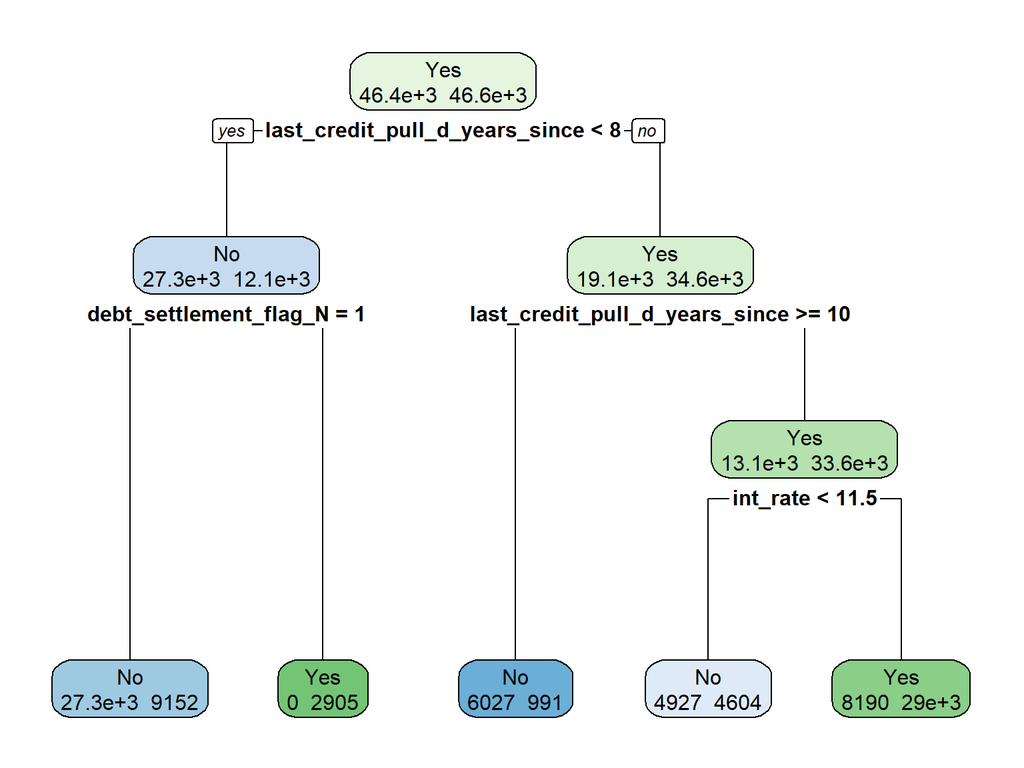

```r
# read in .rds file to avoid refitting
best_tree_dummy_ds <- read_rds("../part2_files/downsampled_dummy_best_tree.rds")
rpart.plot::rpart.plot(best_tree_dummy_ds, type = 2, extra = 1, fallen.leaves = TRUE, digits = 3)
```

```r
# get actual classes and predicted probabilities on holdout
pred_probs <- predict(best_tree_dummy_ds, data_holdout_dummy, type = "prob")[, "Yes"]
true_labels <- ifelse(data_holdout_dummy$loan_default == "Yes", 1, 0)

# get prediction
pred <- ROCR::prediction(pred_probs, true_labels)

# compute metrics on thresholds
perf <- ROCR::performance(pred, measure = "prec", x.measure = "rec")
precision <- perf@y.values[[1]]
recall <- perf@x.values[[1]]
thresholds <- perf@alpha.values[[1]]

# calculate f1
f1 <- 2 * (precision * recall) / (precision + recall)
f1[is.nan(f1)] <- 0

# find best threshold and f1
best_index_dummy_ds <- which.max(f1)
best_thresh_dummy_ds <- thresholds[best_index_dummy_ds]
best_f1_dummy_ds <- f1[best_index_dummy_ds]

# print best threshold and f1
cat("Best threshold:", best_thresh_dummy_ds, "\n")
```

```
## Best threshold: 0.7795899
```

```r
cat("Best F1 score:", best_f1_dummy_ds, "\n")
```

```
## Best F1 score: 0.5642522
```

```r
final_pred <- ifelse(pred_probs >= best_thresh_dummy_ds, "Yes", "No")
confusionMatrix(factor(final_pred, levels = c("No", "Yes")),
                       data_holdout_dummy$loan_default,
                       positive = "Yes")
```

```
## Confusion Matrix and Statistics
##
##           Reference
## Prediction    No   Yes
##        No  52390  5000
##        Yes 11273 10536
##
##                Accuracy : 0.7945
##                  95% CI : (0.7917, 0.7973)
##     No Information Rate : 0.8038
##     P-Value [Acc > NIR] : 1
##
##                   Kappa : 0.4347
##
##  Mcnemar's Test P-Value : <2e-16
##
##             Sensitivity : 0.6782
##             Specificity : 0.8229
##          Pos Pred Value : 0.4831
##          Neg Pred Value : 0.9129
##              Prevalence : 0.1962
##          Detection Rate : 0.1330
##    Detection Prevalence : 0.2754
##       Balanced Accuracy : 0.7505
##
##        'Positive' Class : Yes
##
```

**Finding the optimal threshold by F1 score for the best single, cross-validated decision tree selected by hyperparameter tuning on the downsampled dummy-coded training set results in an optimal threshold of 0.78 and an F1 score of 0.564. The metrics are as follows: accuracy = 0.795, sensitivity = 0.678, and specificity = 0.823.**

# 4 Model Comparison

```r
# compare models
comparison <- data.frame(
  Model = c("Original", "Downsampled", "Dummy", "Dummy + Downsampled"),
  Best_Threshold = c(best_thresh_og, best_thresh_ds, best_thresh_dummy, best_thresh_dummy_ds),
  Best_F1 = c(best_f1_og, best_f1_ds, best_f1_dummy, best_f1_dummy_ds)
)
comparison <- comparison[order(-comparison$Best_F1), ]
print(comparison)
```

```
##                 Model Best_Threshold   Best_F1
## 3               Dummy      0.3047104 0.5666049
## 2         Downsampled      0.6103775 0.5651818
## 4 Dummy + Downsampled      0.7795899 0.5642522
## 1            Original      0.5049838 0.5528781
```

**The model comparison above shows that the model fit using the dummy-coded training data set results in the highest F1 score, while the model fit using the downsampled training data set results in the second highest F1 score. The threshold between these two models are quite different, and logically speaking, the first makes the most sense as the cost of predicting false negatives would be higher than the cost of predicting false positives, so the lower threshold is more reasonable.**

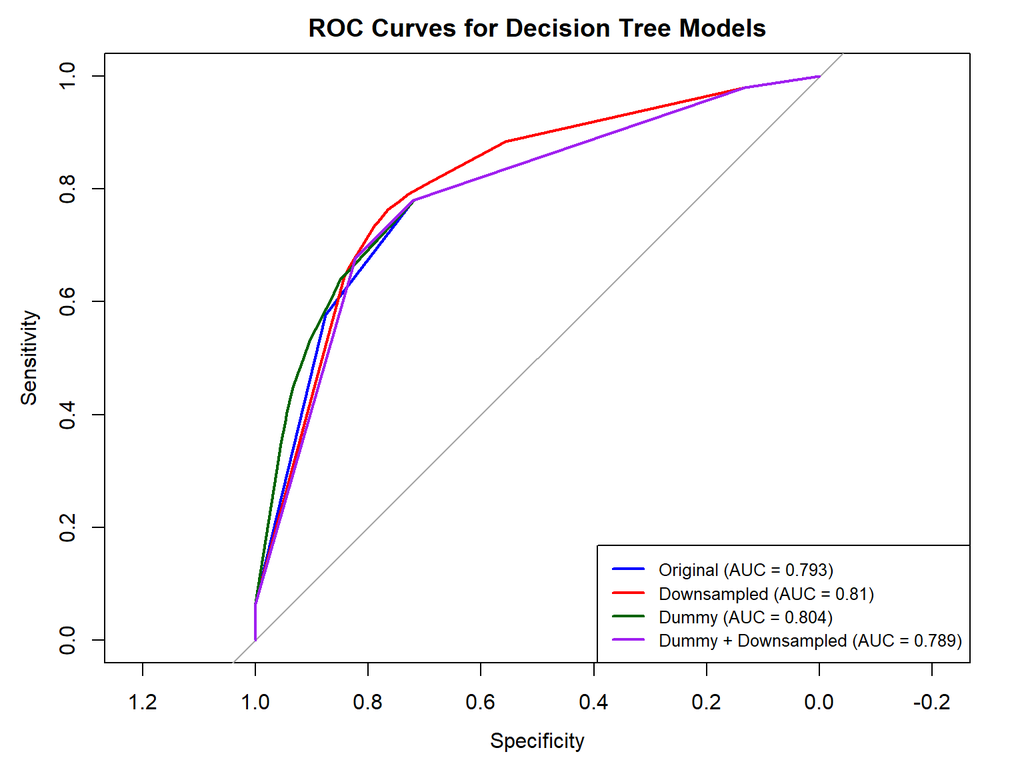

```r
# compare models by plotting ROC curves
roc_og <- pROC::roc(data_holdout$loan_default, predict(best_tree_og, data_holdout, type = "prob")[, "Yes"])
roc_ds <- pROC::roc(data_holdout$loan_default, predict(best_tree_ds, data_holdout, type = "prob")[, "Yes"])
roc_dummy <- pROC::roc(data_holdout_dummy$loan_default, predict(best_tree_dummy, data_holdout_dummy, type = "prob")[, "Yes"])
roc_dummy_ds <- pROC::roc(data_holdout_dummy$loan_default, predict(best_tree_dummy_ds, data_holdout_dummy, type = "prob")[, "Yes"])

plot(roc_og, col = "blue", lwd = 2, main = "ROC Curves for Decision Tree Models")
plot(roc_ds, add = TRUE, col = "red", lwd = 2)
plot(roc_dummy, add = TRUE, col = "darkgreen", lwd = 2)
plot(roc_dummy_ds, add = TRUE, col = "purple", lwd = 2)

legend("bottomright",
       legend = c(
         paste0("Original (AUC = ", round(pROC::auc(roc_og), 3), ")"),
         paste0("Downsampled (AUC = ", round(pROC::auc(roc_ds), 3), ")"),
         paste0("Dummy (AUC = ", round(pROC::auc(roc_dummy), 3), ")"),
         paste0("Dummy + Downsampled (AUC = ", round(pROC::auc(roc_dummy_ds), 3), ")")
       ),
       col = c("blue", "red", "darkgreen", "purple"),
       lwd = 2,
       cex = 0.8)
```

**The ROC curve comparison above shows similar curves for all four models. In terms of AUC, the model fit using the downsampled training data set has the highest value at 0.81, and the model fit using the dummy-coded training data set has the second highest value at 0.804.**

# 5 Final Model